# Point Cluster

Python Version: 2.7

Libraries used: math, random and division from future

## Libraries

```python
import math # sqrt function
from random import randint
import random # creates random number, and sets seed
from __future__ import division # dividing number
import pandas as pd #reading csv
import matplotlib.pyplot as plt #used to plot the graph
%matplotlib inline
```

## Point class

```python
class Point():
    def __init__(self, x, y): #initialising the x and y value of the coordinates
        self.x = x
        self.y = y

    def distance(self, other): #calculating the euclidean distance using pythagoras theorem
        dx = (self.x - other.x) ** 2
        dy = (self.y - other.y) ** 2
        dis = math.sqrt((abs(dx) + abs(dy))) #absolute value of x and y
        return(dis)

    def __getitem__(self, index): #MAYBE?????
        if index == 0:
            return(self.x)
        elif index == 1:
            return(self.y)

    def __repr__(self):
        return('(%s, %s)' % (self.x, self.y)) # Formats the display of the points as x, y

    def __eq__(self, other):
        return self.x == other.x and self.y == other.y #ensures points can be compared

    def __hash__(self): #ensures the point is hashable in the case of putting it into a dict
        return hash(str(self))
```

## Random points class

```python
class Generate_points():
    def __init__(self):
        self.lists = [] #creates empty list for the points

    def insert_point(self, object): #inserts point into the point list
        if object not in self.lists: #ensures no two same points can be added
            self.lists.append(object)

    def remove_point(self, object):
        if object in self.lists: #removes the point from the list, if it exists
            self.lists.remove(object)

    def generate_point(self, n): #generates a specified range of points
        for i in range(n):
            self.insert_point(Point(randint(-100, 100), randint(-100, 100))) # gen point with x, y within range
        return(self.lists)
```

## Partitioning, MCST and clustering class

```python
'''
The Union-Find and mcst(kruskal) was inspired by the introduction to
algorithm book on page 571 (disjoint-set) and 631 (kruskal). The function uses the union-find
partition to find the minimum cost spanning tree and the k-cluster. The find with and without
path compression was from the pseudocode on https://en.wikipedia.org/wiki/Disjoint-set_data_structure
'''
class Partition():
    def __init__(self): #initialises the storage for the cluster and points
        self.points = []
        self.point_distance = []
        self.cluster = []
        self.kcluster = {}
        self.k_num = 0

    def make_set(self, point):
        point.parent = point #assigns the parent of the point as self
        point.rank = 0 #rank of the point is 0
        self.points.append(point) #appends the point to the list

    #find without path compression
    def find_non_pc(self, point):
        if point == point.parent: # find if parent is equivalent to itself
            return point
        else:
            return self.find_non_pc(point.parent)

    #find with path compression
    def find(self, point):
        if point != point.parent:
            point.parent = self.find(point.parent) #if the point is not same as parent call recursion
        return point.parent

    def union(self, point1, point2):
        return(self.link(self.find(point1), self.find(point2)))

    def link(self, point1, point2):
        if point1.rank > point2.rank: #checks if poin1 has higher rank than point2, if so, assign parent
            point2.parent = point1
        else:
            point1.parent = point2
            if point1.rank == point2.rank:
                point2.rank += 1 #if the parent point are the same, increase point2 rank

    def add_points(self, pass_points):
        self.point_distance = [] #Resets the initialised list
        self.points = []
        for point1 in pass_points:
            self.make_set(point1) #run make_set on all inputed points, assigns them with rank and parent
            for point2 in pass_points:
                if point1 != point2: #code below calculates distance between all points, stores them as tuples
                    self.point_distance.append((point1.distance(point2), point1, point2))

    def mcst(self):
        self.cluster = []
        lists = self.point_distance
        sort = sorted(lists, key = lambda lists: lists[0]) #sort the tuple in the list by distance
        for sort_points in sort:
            point1, point2 = sort_points[1], sort_points[2] #extract point 1 and 2 in the list
            find1, find2 = self.find(point1), self.find(point2)
            if find1 != find2:
                self.cluster.append((find1, find2)) #appends the parent in a tuple format
                self.union(find1, find2) #if criteria is met, sets p1 parent as p2, increases rank of p2
                if (len(self.cluster) == (len(self.points)-1)): break #break if there only one partition left
        return(self.cluster)

    def k_cluster(self, k):
        unionfind = Partition() #calling another partition class
        self.kcluster = {}
        self.k_num = 0 #reseting the list so function can be called again
        for point in self.points:
            unionfind.make_set(point)
            unionfind.k_num += 1 #sets the number of points inputed as the initial kluster number
        lists = self.point_distance
        sort = sorted(lists, key = lambda lists: lists[0]) #sorts the point graph list by distance

        while unionfind.k_num > k: #computes partition for the set of points until the k value is met - contrained
            for sort_points in sort:
                point1, point2 = sort_points[1], sort_points[2]
                find1, find2 = unionfind.find(point1), unionfind.find(point2)
                if find1 != find2: break
            unionfind.union(point1, point2)
            unionfind.k_num -= 1

        # output inspired by - https://github.com/topliceanu/learn/blob/master/algo/src/clustering.py
        holder = []
        for point in self.points:
            parent = unionfind.find(point)
            if parent not in holder:
                holder.append(parent)
                self.kcluster[parent] = []
            self.kcluster[parent].append(point) #appends the point to a dictionary
        return(self.kcluster)

    def point_in_clusters(self, point1, point2):
        if point1 == point2:
            return('You have entered the same points, enter the points again')
        for i in self.kcluster.values():
            if set([point1, point2]).issubset(i) == True: #if point1 and point2 are in the list
                print 'Yes both points are in the same cluster: ', i
                return None
                break
            else: pass
        print 'No, the points', point1, 'and', point2, 'are not in the same cluster'

    def dunn_index(self):
        centroids = []
        min_distances = []
        max_distances = []

        def max_clus_distance(mypoints): #function-calculates the maximum distance within each clusters
            distances = []
            for i in mypoints:
                for j in mypoints:
                    if i != j:
                        distances.append(i.distance(j))
            return(max(distances)) #returns the maximum distance in that list

        for i in self.kcluster.values():
            x = [point.x for point in i] #finds all x of the points within the list
            y = [point.y for point in i]
            centroids.append((Point(float(sum(x))/len(i), float(sum(y))/len(i)))) #finds all centroids
            if len(i) > 1:
                max_distances.append(max_clus_distance(i))

        for point1 in centroids:
            for point2 in centroids:
                if point1 != point2:
                    min_distances.append(point1.distance(point2))
        return(min(min_distances)/max(max_distances))
```

### Generating random points

```python
#setting random seed to ensure same result are printed. Remove seed to generate random points
random.seed(1234)
partition = Partition()
test = Generate_points()
set_of_points = test.generate_point(20)
print 'These are 10 generated points ->', set_of_points
```

[output not shown]

#### Adding the points into the partition

```python
partition.add_points(set_of_points)
```

#### Finding the minimum cost spanning tree of the added points

```python
print partition.mcst()
```

[output not shown]

#### Finding the 15 Clusters

```python
partition.k_cluster(15)
```

```
{(-99, -72): [(-99, -72)],
 (-64, -78): [(-64, -78)],
 (-31, 25): [(-31, 25)],
 (94, -12): [(94, -12)],
 (-99, 83): [(-99, 83)],
 (88, 17): [(88, 17)],
 (54, -53): [(54, -53)],
 (16, -46): [(16, -46)],
 (20, -83): [(34, -84), (23, -71), (20, -83)],
 (-97, 2): [(-98, -3), (-97, 2)],
 (11, 29): [(11, 29)],
 (-50, 87): [(-50, 87)],
 (-9, 6): [(8, -7), (-4, -29), (-9, 6)],
 (93, -88): [(93, -88)],
 (-94, 58): [(-94, 58)]}
```

```python
partition.point_in_clusters(Point(34, -84), Point(23, -71))
```

```
Yes both points are in the same cluster:  [(34, -84), (23, -71), (20, -83)]
```

#### Checking the Dunn Index of the 15 clusters

```python
partition.dunn_index()
```

```
0.7211102550927978
```

## Comparing the k-cluster with the miminum clustering spanning tree

The minimum cost spanning tree looks at point and determines all of the edges and computes the mimumum shortest distance between each points. It connects all points/partial tree together forming one large tree. In this case it can be seen that the large tree is simply one cluster. However in k-clustering, given a certain k, only k amount of clusters will be created, hence not all partial tree will be combined to one single tree.

If k is 15, as shown previously, 15 clusters will be found from the points. Each one of those clusters have ranges of points that are considered relatively close to each other when compared to points in another cluster. Usually edges that are within the MCST but not in the forest are edges that are standalone single-point cluster. For example, 4 clusters in total, 2 of the clusters are made of 3 points and the other 2 are made of single points. The single point cluster cannot form edges, as in order to calculate the distance, it requires more than 1 point.

## Real world data - Park Points

In data science there notably two types of learning process and that is supervised learning and unsupervised learning. Supervised learning uses the concep of labeled data for training, however labeled data are not always available, hence unsupervised learning is used to find hidden structure in unlabelled data. That is when given a lot of data, determine which of the points of the data are similar to each other.

This can be used in terms of finding which points in a set is close to a certain point. The Australia government had provided a dataset which gives the geographical information, latitude and longitude of parks in brisbane. The dataset can be found here - https://data.gov.au/dataset/parks-points/resource/fea690c1-d359-4d40-9ba3-b551670f759b.

I often go to a gym called Snapfitness in Meadowbrook when I visit my friends in brisbane. As there are number of parks in the area, I often wonder which park should I go to after gym to finish my workout off with some running. The clustering algorithm will be used to determine which of the parks are closests to the gym.

#### Reading in the csv as park_points

```python
park_points = pd.read_csv('Parks_Points.csv')
print 'Viewing the first 3 rows'
park_points.head(3)
```

```
Viewing the first 3 rows
```

|  | X | Y | OBJECTID | Park_Name | Location | Park_Type | Comment | Park_ID | BBQ_Electric | BBQ_Wood | ... | Picnic_Area | Playground | Skate_Facilities | Toilets | Wheelchair_Toilets | Volleyball | Walking_Track | Waterfront | Hyperlink | Processed |
| --- | --- | --- | --- | --- | --- | --- | --- | --- | --- | --- | --- | --- | --- | --- | --- | --- | --- | --- | --- | --- | --- |
| 0 | 153.187106 | -27.746483 | 1 | ACTIVITY PARK | 3 ERNEST STREET, WINDAROO | Parks | NaN | 728 | NaN | NaN | ... | NaN | <img style="VERTICAL-ALIGN: middle" title="Pla... | <img style="VERTICAL-ALIGN: middle" title="Ska... | NaN | NaN | NaN | NaN | NaN | /parks-directory/activity-park | 2016-10-23T02:30:22.000Z |
| 1 | 153.179734 | -27.653989 | 2 | ADELONG PARK | ADELONG ROAD, SHAILER PARK | Parks | NaN | 6 | NaN | NaN | ... | <img style="VERTICAL-ALIGN: middle" title="Sha... | <img style="VERTICAL-ALIGN: middle" title="Pla... | NaN | NaN | NaN | NaN | NaN | NaN | /parks-directory/adelong-park | 2016-10-23T02:30:25.000Z |
| 2 | 153.103551 | -27.631742 | 3 | ALBERT PARK | HAGUE STREET,WOODRIDGE | Parks | NaN | 9 | NaN | NaN | ... | <img style="VERTICAL-ALIGN: middle" title="Sha... | <img style="VERTICAL-ALIGN: middle" title="Pla... | NaN | NaN | NaN | NaN | NaN | NaN | /parks-directory/albert-park | 2016-10-23T02:30:25.000Z |

3 rows × 31 columns

#### Total of 102 parks in the brisbane area

```python
park_points.shape
```

```
(102, 31)
```

#### Checking all column names

```python
park_points.columns
```

```
Index([u'X', u'Y', u'OBJECTID', u'Park_Name', u'Location', u'Park_Type',
       u'Comment', u'Park_ID', u'BBQ_Electric', u'BBQ_Wood', u'Basketball',
       u'Bike_Track', u'BMX', u'Boat_Ramp', u'Bocce', u'Cricket_Practice_Net',
       u'Disc_Golf', u'Dog_Off_Leash_Area', u'Fishing_Pontoon',
       u'Fitness_Equipment', u'Ideal_Wedding_Location', u'Picnic_Area',
       u'Playground', u'Skate_Facilities', u'Toilets', u'Wheelchair_Toilets',
       u'Volleyball', u'Walking_Track', u'Waterfront', u'Hyperlink',
       u'Processed'],
      dtype='object')
```

```python
park_points.columns.values[0] = 'long'
park_points.columns.values[1] = 'lat'
park_points.columns.values[2] = 'id'
park_points.columns.values[3] = 'name'
```

#### Subsetting the columns and renaming

```python
subset = park_points.ix[:,0:5]
```

#### Appending the location to the points

```python
park_points_set = Generate_points()
partition_pp = Partition()
snapfitness = Point(153.1061546, -27.6656176)
park_points_set.insert_point(snapfitness)
for i in range(0, len(subset)):
    park_points_set.insert_point(Point(subset['long'][i], subset['lat'][i]))
partition_pp.add_points(park_points_set.lists)
```

#### Pairs of points for the minimum cost spanning tree

```python
partition_pp.mcst()
```

```
[((153.1061546, -27.6656176), (153.107298925, -27.665709648)),
 ((153.051921845, -27.6613497932), (153.051675598, -27.6648662625)),
 ((153.229632234, -27.7086057574), (153.226148884, -27.7092526104)),
 ((152.996445045, -27.6632401769), (153.000376183, -27.6650132244)),
 ((153.189217271, -27.7003215264), (153.193114859, -27.6983406146)),
 ((153.19135698, -27.7376876082), (153.195877854, -27.7362979003)),
 ((153.1029697, -27.6527855667), (153.106177221, -27.6563402341)),
 ((153.11398614, -27.6558951732), (153.114777125, -27.6507641666)),
 ((153.187106265, -27.7464825249), (153.191960182, -27.7445348043)),
 ((153.106177221, -27.6563402341), (153.103550035, -27.6474768843)),
 ((153.107298925, -27.665709648), (153.11060429, -27.6702964078)),
 ((153.134017291, -27.6260599369), (153.138346926, -27.6298585767)),
 ((153.106177221, -27.6563402341), (153.101172401, -27.6593614702)),
 ((153.21027499, -27.7035896817), (153.204598138, -27.7050995675)),
 ((153.048042805, -27.6696112177), (153.051675598, -27.6648662625)),
 ((153.111677844, -27.6334362167), (153.117646615, -27.63245395)),
 ((153.17465568, -27.6814176656), (153.168596125, -27.6804797695)),
 ((153.081654545, -27.6932858766), (153.084159576, -27.6875678335)),
 ((153.105719088, -27.6165200883), (153.104286668, -27.6100547949)),
 ((153.195877854, -27.7362979003), (153.191960182, -27.7445348043)),
 ((153.110683631, -27.6830729985), (153.107704775, -27.6768406366)),
 ((153.107298925, -27.665709648), (153.107704775, -27.6768406366)),
 ((153.106177221, -27.6563402341), (153.105838214, -27.6405302243)),
 ((153.1035505, -27.6317421997), (153.096973156, -27.6354043245)),
 ((153.104286668, -27.6100547949), (153.113078414, -27.6147220938)),
 ((153.138346926, -27.6298585767), (153.143350319, -27.6241495649)),
 ((153.196996794, -27.7061959358), (153.204598138, -27.7050995675)),
 ((153.114777125, -27.6507641666), (153.106177221, -27.6563402341)),
 ((153.107704775, -27.6768406366), (153.106177221, -27.6563402341)),
 ((153.184157882, -27.6412104689), (153.177017992, -27.644820831)),
 ((153.140031252, -27.6920036107), (153.132307311, -27.6942363995)),
 ((153.096973156, -27.6354043245), (153.117646615, -27.63245395)),
 ((153.192508842, -27.7616566664), (153.184376413, -27.759578108)),
 ((153.033206576, -27.6637788812), (153.024704279, -27.664253663)),
 ((153.027256361, -27.6939133785), (153.01910184, -27.6913728076)),
 ((153.128842672, -27.6863612759), (153.132307311, -27.6942363995)),
 ((153.051235584, -27.6865601125), (153.057829053, -27.6809767977)),
 ((153.166601017, -27.6445982068), (153.159045099, -27.6488112099)),
 ((153.204598138, -27.7050995675), (153.193114859, -27.6983406146)),
 ((153.129955969, -27.6412668749), (153.127087174, -27.6329113648)),
```

[output cut: 47 more lines]

```
 ((152.998807854, -27.8269458306), (153.022978167, -27.8303438751)),
 ((153.106177221, -27.6563402341), (153.024704279, -27.664253663)),
 ((153.106177221, -27.6563402341), (153.191960182, -27.7445348043)),
 ((152.982505708, -27.7300574766), (153.012642829, -27.7377384281)),
 ((153.124060388, -27.7412768382), (153.105515925, -27.7682511259)),
 ((153.045057287, -27.7297990381), (153.012642829, -27.7377384281)),
 ((153.106177221, -27.6563402341), (153.012642829, -27.7377384281)),
 ((152.978539498, -27.8593957106), (153.022978167, -27.8303438751)),
 ((153.263638938, -27.6691325861), (153.106177221, -27.6563402341)),
 ((153.022978167, -27.8303438751), (152.973119234, -27.9008185204)),
 ((153.009686759, -27.7824122152), (153.106177221, -27.6563402341)),
 ((153.022978167, -27.8303438751), (153.106177221, -27.6563402341)),
 ((153.106177221, -27.6563402341), (152.945286281, -27.8261260145)),
 ((153.105515925, -27.7682511259), (153.106177221, -27.6563402341)),
 ((153.106177221, -27.6563402341), (152.92543873, -27.7373757348))]
```

#### Finding the best k for the k-cluster

```python
k_num, dunn_index = [], []
for i in range(2, len(subset)):
    partition_pp.k_cluster(i)
    k_num.append(i)
    dunn_index.append(partition_pp.dunn_index())
table = pd.DataFrame({'k_num':k_num, 'dunn_index':dunn_index})
table.head(5)
```

|  | dunn_index | k_num |
| --- | --- | --- |
| 0 | 0.535419 | 2 |
| 1 | 0.189140 | 3 |
| 2 | 0.193231 | 4 |
| 3 | 0.210310 | 5 |
| 4 | 0.210310 | 6 |

#### Plotting out the dunn index in respect the the k number

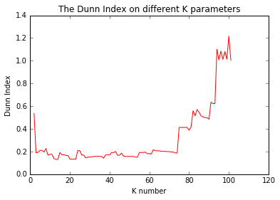

```python
plt.plot(table.k_num, table.dunn_index, 'r-')
plt.xlabel('K number')
plt.ylabel("Dunn Index")
plt.title('The Dunn Index on different K parameters')
```

As shown above the best k seems to be a k of 100 as it has the highest dunn index. Hence a K of 100 will be used in this case to find the park that is closests the snapfitness Meadowbrook.

```python
for i in partition_pp.k_cluster(100).values():
    if snapfitness in i:
        print i
print 'Rounded coordinateds -> ', round(153.107298925,6), round(-27.665709648, 6)
```

```
[(153.1061546, -27.6656176), (153.107298925, -27.665709648)]
Rounded coordinateds ->  153.107299 -27.66571
```

#### The park closests to snapfitness has the coordinates (153.107299, -27.66571)

```python
subset['long'] = subset['long'].round(6)
subset['lat'] = subset['lat'].round(6)
subset[(subset['long'] == 153.107299) & (subset['lat'] == -27.66571)]
```

|  | long | lat | id | name | Location |
| --- | --- | --- | --- | --- | --- |
| 12 | 153.107299 | -27.66571 | 13 | BEGA PARK | BEGA ROAD,KINGSTON |

#### Conclusion of findings

The park that is closests to Snapfitness Meadowbrook is Bega park on Bega Road, Kingston. The cluster was used to determine the closests point, using euclidean distance to that gym. This was done using the concept of 100 clusters, as it produced the highest dunn index, where it indicates high intra-cluster similarity and low inter-cluster similarity.

## References

- Cormen, T, Leiserson, C, Rivest, R, Stein, C 2009, 'Introduction to Algorithms', Third Edition, Massachusetts Institute of Technology